# ML - RANDOM FOREST DECISION TREES SESSION- PRACTICAL 6

### The major challenge in heart diseases is its detection.There are instruments to predict heart diseases in patients but are expensive/inefficient. Yet early detection of the heart diseases can help decrease the mortality rate and complications. We can use various ML algorithms to analyse the heart related data for hidden patterns can help in early detection of heart diseases.

```python
# importing the libraries
#  we are using the seaborn for the advanced visualization
#  %matplotlib inline - this is used because then we do not have to plt.show while
# generating the graph

import numpy as np
import pandas as pd
import matplotlib.pyplot as plt
import seaborn as sns
%matplotlib inline
```

```python
# here we have created the variable called df
# then by using the pandas library we are reading the heart csv file

df = pd.read_csv('heart.csv')
```

```python
# here we are checking the shape of the dataset

df.shape
```

```
(1025, 14)
```

```python
# here we are checking the information present in the dataset

df.info()
```

```
<class 'pandas.core.frame.DataFrame'>
RangeIndex: 1025 entries, 0 to 1024
Data columns (total 14 columns):
 #   Column    Non-Null Count  Dtype
---  ------    --------------  -----
 0   age       1025 non-null   int64
 1   sex       1025 non-null   int64
 2   cp        1025 non-null   int64
 3   trestbps  1025 non-null   int64
 4   chol      1025 non-null   int64
 5   fbs       1025 non-null   int64
 6   restecg   1025 non-null   int64
 7   thalach   1025 non-null   int64
 8   exang     1025 non-null   int64
 9   oldpeak   1025 non-null   float64
 10  slope     1025 non-null   int64
 11  ca        1025 non-null   int64
 12  thal      1025 non-null   int64
 13  target    1025 non-null   int64
dtypes: float64(1), int64(13)
memory usage: 112.2 KB
```

```python
# here we are checking the initial 5 rows of the dataset

df.head()
```

|  | age | sex | cp | trestbps | chol | fbs | restecg | thalach | exang | oldpeak | slope | ca | thal | target |
| --- | --- | --- | --- | --- | --- | --- | --- | --- | --- | --- | --- | --- | --- | --- |
| 0 | 52 | 1 | 0 | 125 | 212 | 0 | 1 | 168 | 0 | 1.0 | 2 | 2 | 3 | 0 |
| 1 | 53 | 1 | 0 | 140 | 203 | 1 | 0 | 155 | 1 | 3.1 | 0 | 0 | 3 | 0 |
| 2 | 70 | 1 | 0 | 145 | 174 | 0 | 1 | 125 | 1 | 2.6 | 0 | 0 | 3 | 0 |
| 3 | 61 | 1 | 0 | 148 | 203 | 0 | 1 | 161 | 0 | 0.0 | 2 | 1 | 3 | 0 |
| 4 | 62 | 0 | 0 | 138 | 294 | 1 | 1 | 106 | 0 | 1.9 | 1 | 3 | 2 | 0 |

```python
# here we are checking the numerical columns present in the dataset

df.describe()
```

|  | age | sex | cp | trestbps | chol | fbs | restecg | thalach | exang | oldpeak | slope | ca | thal | target |
| --- | --- | --- | --- | --- | --- | --- | --- | --- | --- | --- | --- | --- | --- | --- |
| count | 1025.000000 | 1025.000000 | 1025.000000 | 1025.000000 | 1025.00000 | 1025.000000 | 1025.000000 | 1025.000000 | 1025.000000 | 1025.000000 | 1025.000000 | 1025.000000 | 1025.000000 | 1025.000000 |
| mean | 54.434146 | 0.695610 | 0.942439 | 131.611707 | 246.00000 | 0.149268 | 0.529756 | 149.114146 | 0.336585 | 1.071512 | 1.385366 | 0.754146 | 2.323902 | 0.513171 |
| std | 9.072290 | 0.460373 | 1.029641 | 17.516718 | 51.59251 | 0.356527 | 0.527878 | 23.005724 | 0.472772 | 1.175053 | 0.617755 | 1.030798 | 0.620660 | 0.500070 |
| min | 29.000000 | 0.000000 | 0.000000 | 94.000000 | 126.00000 | 0.000000 | 0.000000 | 71.000000 | 0.000000 | 0.000000 | 0.000000 | 0.000000 | 0.000000 | 0.000000 |
| 25% | 48.000000 | 0.000000 | 0.000000 | 120.000000 | 211.00000 | 0.000000 | 0.000000 | 132.000000 | 0.000000 | 0.000000 | 1.000000 | 0.000000 | 2.000000 | 0.000000 |
| 50% | 56.000000 | 1.000000 | 1.000000 | 130.000000 | 240.00000 | 0.000000 | 1.000000 | 152.000000 | 0.000000 | 0.800000 | 1.000000 | 0.000000 | 2.000000 | 1.000000 |
| 75% | 61.000000 | 1.000000 | 2.000000 | 140.000000 | 275.00000 | 0.000000 | 1.000000 | 166.000000 | 1.000000 | 1.800000 | 2.000000 | 1.000000 | 3.000000 | 1.000000 |
| max | 77.000000 | 1.000000 | 3.000000 | 200.000000 | 564.00000 | 1.000000 | 2.000000 | 202.000000 | 1.000000 | 6.200000 | 2.000000 | 4.000000 | 3.000000 | 1.000000 |

```python
#  here we are checking for all the null values or the missing values present in the dataset

df.isnull()
```

|  | age | sex | cp | trestbps | chol | fbs | restecg | thalach | exang | oldpeak | slope | ca | thal | target |
| --- | --- | --- | --- | --- | --- | --- | --- | --- | --- | --- | --- | --- | --- | --- |
| 0 | False | False | False | False | False | False | False | False | False | False | False | False | False | False |
| 1 | False | False | False | False | False | False | False | False | False | False | False | False | False | False |
| 2 | False | False | False | False | False | False | False | False | False | False | False | False | False | False |
| 3 | False | False | False | False | False | False | False | False | False | False | False | False | False | False |
| 4 | False | False | False | False | False | False | False | False | False | False | False | False | False | False |
| ... | ... | ... | ... | ... | ... | ... | ... | ... | ... | ... | ... | ... | ... | ... |
| 1020 | False | False | False | False | False | False | False | False | False | False | False | False | False | False |
| 1021 | False | False | False | False | False | False | False | False | False | False | False | False | False | False |
| 1022 | False | False | False | False | False | False | False | False | False | False | False | False | False | False |
| 1023 | False | False | False | False | False | False | False | False | False | False | False | False | False | False |
| 1024 | False | False | False | False | False | False | False | False | False | False | False | False | False | False |

1025 rows × 14 columns

```python
# here we are checking the sum of all the null values or the missing values present in the dataset

df.isnull().sum()
```

```
age         0
sex         0
cp          0
trestbps    0
chol        0
fbs         0
restecg     0
thalach     0
exang       0
oldpeak     0
slope       0
ca          0
thal        0
target      0
dtype: int64
```

```python
# data is balanced
# here we have using the raget column of the dataset so we have used the box brackets .
# given the column name as target
# then we  will do the value counts for the target
# it will check that how many zeros and ones we have in our data .
# value_counts - it is the function so we have used the round bracket .
# here  we have 526 ones and 499 zeros .
# target variable is the categorical variable .
#  if we want to see the distribution / categorical variable  then we use the bar plot .

df['target'].value_counts()
```

```
1    526
0    499
Name: target, dtype: int64
```

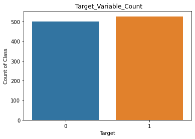

```python
# here we want to see the count of the categorical variable so we will use the count plot
# here we will use the seaborn library  and select the countplot
# then we have selected the target column from the dataset
# then we will set the x label and the y label
# then we will set the title
#  then we will use the plt.show() to get the permanent output .

sns.countplot(df['target'])
plt.xlabel("Target")
plt.ylabel("Count of Class")
plt.title(" Target_Variable_Count")
plt.show()
```

```python
# creating subset of features and dependent variable
# here we have created the two variable named X nad Y .
# here we have selected the dataset
# then we have used the iloc function to slice the dataframes
# then we have selected the rows and selected all the columns and we left the last column
# ideally -1 is used for the last column
# then for the y we have used the iloc function
# then we have selected all the rows and  here we have selected the last column .
# there is basic difference between these 2 codes ;
# X = df.iloc[:,:-1]
# y = df.iloc[:,-1]
# in the 1st code we have selected all the columns so mentioned the colon but not the
# last column  and left the last column as -1
#  and secondly we have selected the nothing but we have selected the last column
# we mention the range with the colon operator

X = df.iloc[:,:-1]
y = df.iloc[:,-1]

# iloc function is used to slice dataframes
```

```python
# here we are checking for the feature X

X
```

|  | age | sex | cp | trestbps | chol | fbs | restecg | thalach | exang | oldpeak | slope | ca | thal |
| --- | --- | --- | --- | --- | --- | --- | --- | --- | --- | --- | --- | --- | --- |
| 0 | 52 | 1 | 0 | 125 | 212 | 0 | 1 | 168 | 0 | 1.0 | 2 | 2 | 3 |
| 1 | 53 | 1 | 0 | 140 | 203 | 1 | 0 | 155 | 1 | 3.1 | 0 | 0 | 3 |
| 2 | 70 | 1 | 0 | 145 | 174 | 0 | 1 | 125 | 1 | 2.6 | 0 | 0 | 3 |
| 3 | 61 | 1 | 0 | 148 | 203 | 0 | 1 | 161 | 0 | 0.0 | 2 | 1 | 3 |
| 4 | 62 | 0 | 0 | 138 | 294 | 1 | 1 | 106 | 0 | 1.9 | 1 | 3 | 2 |
| ... | ... | ... | ... | ... | ... | ... | ... | ... | ... | ... | ... | ... | ... |
| 1020 | 59 | 1 | 1 | 140 | 221 | 0 | 1 | 164 | 1 | 0.0 | 2 | 0 | 2 |
| 1021 | 60 | 1 | 0 | 125 | 258 | 0 | 0 | 141 | 1 | 2.8 | 1 | 1 | 3 |
| 1022 | 47 | 1 | 0 | 110 | 275 | 0 | 0 | 118 | 1 | 1.0 | 1 | 1 | 2 |
| 1023 | 50 | 0 | 0 | 110 | 254 | 0 | 0 | 159 | 0 | 0.0 | 2 | 0 | 2 |
| 1024 | 54 | 1 | 0 | 120 | 188 | 0 | 1 | 113 | 0 | 1.4 | 1 | 1 | 3 |

1025 rows × 13 columns

```python
# here we are checking for the feature Y

y
```

```
0       0
1       0
2       0
3       0
4       0
       ..
1020    1
1021    0
1022    0
1023    1
1024    0
Name: target, Length: 1025, dtype: int64
```

```python
# using the iloc function on series
# here we have created the variable called series1
# then by using the pamdas library we are creating a series
# series is the function so we have used the round brackets
# then we will past the list of an arguments
# we are creating the list so we have used the box bracket
# and then we will specify our own index which will give us the row identifiers
# and then we have passed the list
# then we have printed the series1
# if we will not use the index parameter we will get the bydefault index as 0,1,2,3,4,5...

series1= pd.Series(['Apple','Orangres','Lemon','Banana'])
series1.index = ['fr1','fr2','fr3','fr4']
print(series1)
```

```
fr1       Apple
fr2    Orangres
fr3       Lemon
fr4      Banana
dtype: object
```